# Logistic Regression

Dusty Turner

August 30, 2018

# Linear Regression: What Was Wrong With What We Were Doing? (Lsn 4)

## Upload and Manipulate Data

The following data has annual player statistics dating back to 1875. We’ll upload it and get it in form for analysis.

```r
library(tidyverse)

battingdata = read_csv("Batting.csv")

batting = battingdata %>%
  group_by(playerID) %>%
  summarise(G = sum(G),
         AB = sum(AB),
         R = sum(R),
         H = sum(H)) %>%
  filter(H>1000) %>%
  select(playerID,H,G,AB,R)

head(batting)
```

```
## # A tibble: 6 x 5
##   playerID      H     G    AB     R
##   <chr>     <int> <int> <int> <int>
## 1 aaronha01  3771  3298 12364  2174
## 2 abreubo01  2470  2425  8480  1453
## 3 adairje01  1022  1165  4019   378
## 4 adamsbo03  1082  1281  4019   591
## 5 adamssp01  1588  1424  5557   844
## 6 adcocjo01  1832  1959  6606   823
```

The following data indicates which players made it into the Hall of Fame

```r
HallOfFame = read_csv("HallOfFame.csv")

HOF = HallOfFame %>%
  filter(category=="Player", inducted =="Y") %>%
  mutate(HOF = 1) %>%
  select(playerID, HOF)

head(HOF)
```

```
## # A tibble: 6 x 2
##   playerID    HOF
##   <chr>     <dbl>
## 1 cobbty01      1
## 2 ruthba01      1
## 3 wagneho01     1
## 4 mathech01     1
## 5 johnswa01     1
## 6 lajoina01     1
```

Lets also make life easier by adding in the names of the players along with their player ID numbers.

```r
masterdata = read_csv("Master.csv")

master = masterdata %>%
  mutate(name = paste(nameFirst,nameLast,sep = " ")) %>%
  select(playerID, name)

head(master)
```

```
## # A tibble: 6 x 2
##   playerID  name
##   <chr>     <chr>
## 1 aardsda01 David Aardsma
## 2 aaronha01 Hank Aaron
## 3 aaronto01 Tommie Aaron
## 4 aasedo01  Don Aase
## 5 abadan01  Andy Abad
## 6 abadfe01  Fernando Abad
```

Lastly, lets join all the data together so we can analyse our question of interest.

```r
fulldata = batting %>%
  left_join(master, by = "playerID") %>%
  left_join(HOF, by = "playerID") %>%
  mutate(HOF = ifelse(is.na(HOF),0,HOF))

head(fulldata)
```

```
## # A tibble: 6 x 7
##   playerID      H     G    AB     R name           HOF
##   <chr>     <int> <int> <int> <int> <chr>        <dbl>
## 1 aaronha01  3771  3298 12364  2174 Hank Aaron       1
## 2 abreubo01  2470  2425  8480  1453 Bobby Abreu      0
## 3 adairje01  1022  1165  4019   378 Jerry Adair      0
## 4 adamsbo03  1082  1281  4019   591 Bobby Adams      0
## 5 adamssp01  1588  1424  5557   844 Sparky Adams     0
## 6 adcocjo01  1832  1959  6606   823 Joe Adcock       0
```

## Fit a Linear Model

Cool, now lets take a *swing* at using our old tool to example the relationship between hits and making the Hall of Fame.

```r
options(scipen = 999)
linmod = lm(HOF~H, fulldata)
summary(linmod)
```

```
##
## Call:
## lm(formula = HOF ~ H, data = fulldata)
##
## Residuals:
##      Min       1Q   Median       3Q      Max
## -0.99903 -0.13965 -0.02338  0.05257  1.03651
##
## Coefficients:
##                Estimate  Std. Error t value            Pr(>|t|)
## (Intercept) -0.42495730  0.02420932  -17.55 <0.0000000000000002 ***
## H            0.00033458  0.00001418   23.60 <0.0000000000000002 ***
## ---
## Signif. codes:  0 '***' 0.001 '**' 0.01 '*' 0.05 '.' 0.1 ' ' 1
##
## Residual standard error: 0.2701 on 1293 degrees of freedom
## Multiple R-squared:  0.301,  Adjusted R-squared:  0.3005
## F-statistic: 556.8 on 1 and 1293 DF,  p-value: < 0.00000000000000022
```

GREAT!! We have significance! Lets talk about this…

## Issues

### Illistration 1: Lets look graphically…

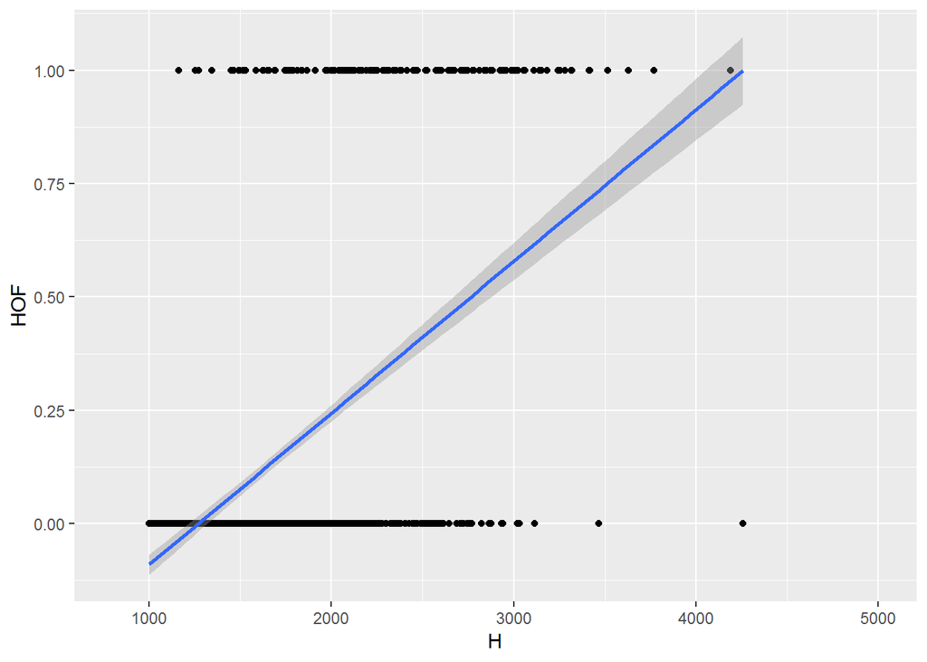

```r
fulldata %>%
  ggplot(aes(x=H,y = HOF)) +
  geom_point() +
  stat_smooth(method = "lm") + ## plots the regression line with prediction interval
  xlim(800,5000)
```

What is going on?

### Illistration 2: Predictions

```r
newdata = tibble(H=c(50,3000,4500))
predict.lm(linmod,newdata = newdata)
```

```
##          1          2          3
## -0.4082282  0.5787900  1.0806636
```

What is this telling us?

### Illistration 3: Residuals

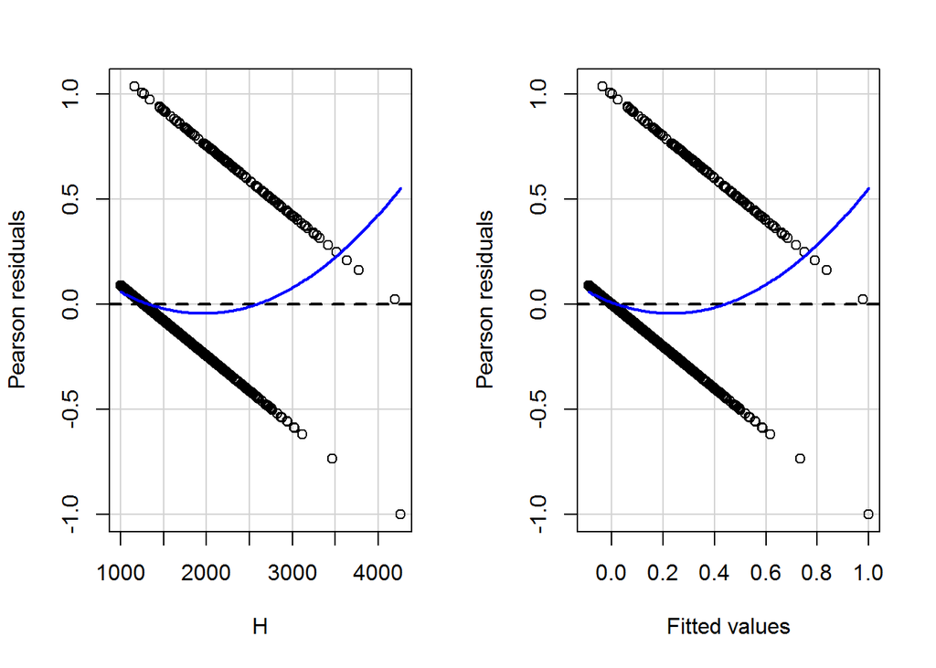

```
##            Test stat Pr(>|Test stat|)
## H              5.973   0.000000003006 ***
## Tukey test     5.973   0.000000002329 ***
## ---
## Signif. codes:  0 '***' 0.001 '**' 0.01 '*' 0.05 '.' 0.1 ' ' 1
```

```r
library(car)
residualPlots(linmod)
```

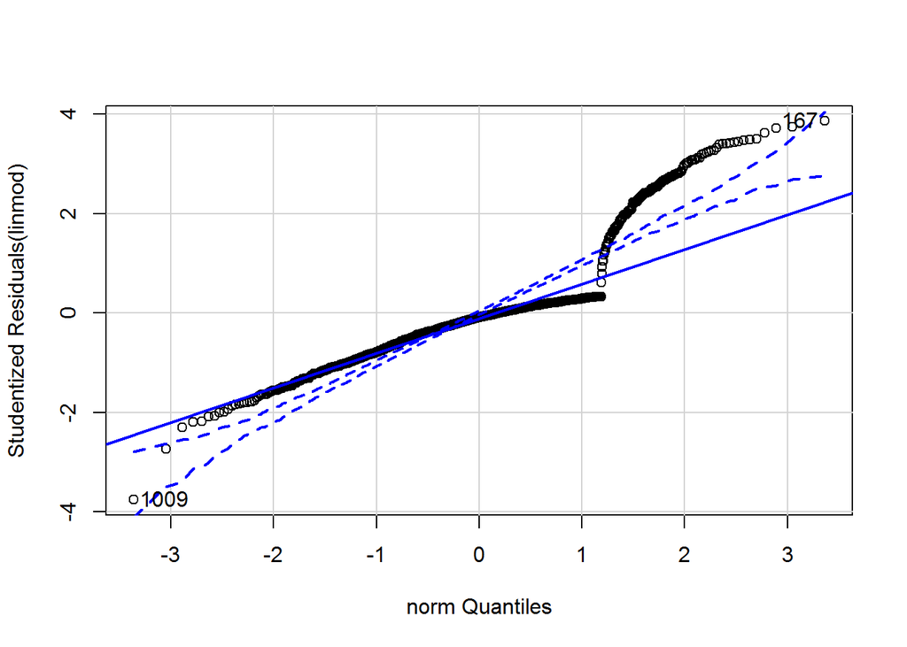

```
## [1]  167 1009
```

```r
qqPlot(linmod, distribution = "norm")
```

# The “Solution”: Logistic Regression

Linear Regression often works well with continuous response variables but typically performs poorly with other types of response variables (binary, count data. etc.). Linear regression is just one technique in a class of models called *Generalized Linear Models*.

## Generalized Linear Models (GLM) have three components:

### 1: A Probability Distribution

- With linear regression, the probability distribution is the normal distribution (the conditional distribution of “Y” given “X” is normal ($p(Y|X) \sim N$); this is another way of saying that the residuals are normally distributed).

### 2: A Systematic Component

- The systematic component is simply the linear function of the $\beta 's$ (i.e. the right hand side of the equation)

### 3: Link Function

- The link function of linear regression is the identity $\mu$. We will investigate another commonly used GLM, logistic regression. As in linear regression, our interest is in modeling or predicting the response variable using a set of predictor variables. But with logistic regression, the response variable is binary.

|  | Linear Regression | Logistic Regression |
| --- | --- | --- |
| Probability Distribution | $y\sim N(\bar{x},\sigma{}_x)$ | $y\sim Binom(1,p_x)$ |
| Systematic Component | $\beta_o+\beta_1x$ | $\beta_o+\beta_1x$ |
| Link Function | $\mu_y=\mu$ | $\mu_y=\ln(\frac{p}{1-p})$ |

## The Simple Logistic Regression Model

### One Way To Look At It

The simple logistic regression model is $E(Y | X) = \pi(X) =\displaystyle \frac{e^{\beta_0+\beta_1 X}} {1+e^{\beta_0+ \beta_1 X}}$ where $Y$ is a binary response variable, $\pi(X)$ is the population proportion of responses for a given value of X, and $\beta_0$ and $\beta_1$ are regression parameters. A simple logistic regression function represents an “S-shaped” curve and has a maximum possible value of 1 and a minimum value of 0.

### Another Way To Look At It

Another way to write the logistic regression model is $Y = \displaystyle \frac{e^{\beta_0+\beta_1 X}} {1+e^{\beta_0+ \beta_1 X}} + \epsilon$ where $\epsilon$ is the error term or the difference between the binary response value and the probability from the logistic regression function, $Y−\pi(X)$. These should look similar to the error term, or residuals, from a linear regression model but they are somewhat different (more to follow on residuals!).

This hurts my head: We’ll come back to this in a few minutes. In the meantime, lets fit our first model.

## Fitting the Logistic Regression in R

```r
logmod = glm(HOF~H, data = fulldata, family = binomial(link="logit"))
summary(logmod)
```

```
##
## Call:
## glm(formula = HOF ~ H, family = binomial(link = "logit"), data = fulldata)
##
## Deviance Residuals:
##     Min       1Q   Median       3Q      Max
## -3.2235  -0.3616  -0.2144  -0.1517   2.9409
##
## Coefficients:
##               Estimate Std. Error z value            Pr(>|z|)
## (Intercept) -7.8751981  0.4616943  -17.06 <0.0000000000000002 ***
## H            0.0030698  0.0002135   14.38 <0.0000000000000002 ***
## ---
## Signif. codes:  0 '***' 0.001 '**' 0.01 '*' 0.05 '.' 0.1 ' ' 1
##
## (Dispersion parameter for binomial family taken to be 1)
##
##     Null deviance: 940.73  on 1294  degrees of freedom
## Residual deviance: 605.56  on 1293  degrees of freedom
## AIC: 609.56
##
## Number of Fisher Scoring iterations: 6
```

## Interpreting the Logistic Regression Model

For a logistic function, there is not a “slope” or “intercept” in the traditional sense. However, $\beta_0$ is still typically referred to as the intercept parameter and $\beta_1$ is typically referred to as the slope parameter.

In the above R output, the estimated intercept parameter is $b_0 = -7.8751981$.

The estimated slope parameter is $b_1 = 0.0030698$.

The estimated logistic regression model is $\ln(\frac{p}{1-p})=\beta_o+\beta_1x$.

After substituting the values into the estimated logistic regression model, we have $\ln(\frac{p}{1-p})=-7.8751981+0.0030698x$.

The positive slope parameter means that (not surprisingly) as Career Hits increases, so does a player’s probability of being inducted into the hall of fame. But how much?

But does our old interpretation of $\beta_1$ hold true for logistic regression? Does a one unit increase in $x$ result in a one unit increase in $E[Y]$? Not so fast.

A one unit increase in $\beta_1$ results in a one unit increase in $\ln(\frac{p}{1-p})$ also known as the “log odds”. What does log odds mean to you? Probably not much. Lets get to something more meaningful: like a probability.

Lets do some algebra:

$\ln(\frac{p}{1-p}) = \beta_o+\beta_1x$

Lets solve for `p`.

$\frac{p}{1-p} = e^{\beta_o+\beta_1x}$

$p =(1-p)e^{\beta_o+\beta_1x}$

$p =e^{\beta_o+\beta_1x}-pe^{\beta_o+\beta_1x}$

$p+pe^{\beta_o+\beta_1x} =e^{\beta_o+\beta_1x}$

$p(1+e^{\beta_o+\beta_1x}) =e^{\beta_o+\beta_1x}$

$p =\frac{e^{\beta_o+\beta_1x}}{1+e^{\beta_o+\beta_1x}}$

WE’VE SEEN THIS BEFORE!!!

### Estimating probabilities

To estimate the probability that a player is inducted into the Hall of Fame (P(Y=1)), you simply substitute his “X” value, Career Hits, into the regression model. For a player with 2000 Career Hits, the estimated probability of being inducted into the hall of fame is $\hat{\pi}(2000) = \displaystyle \frac{e^{-7.8751981+0.0030698*2000}} {1+e^{-7.8751981+0.0030698*2000}} = 0.1498665$

### Multiple Logistic Regression

As with other types of regression models, it is often not adequate to consider only a single predictor variable. The logistic regression model with the two predictors is $E(Y | X) = \pi({\bf X}) = \displaystyle \frac{e^{\beta_0 + \beta_1 X_1 + \beta_2 X_2}} {1+e^{\beta_0+ \beta_1 X_1 + \beta_2 X_2}}$.

## Logistic Regression Outcomes in R

We could do this by hand every time, but that is painful. Lets see how we can do it in R.

```r
predict.glm(logmod,newdata = data.frame(H=2000))
```

```
##         1
## -1.735649
```

Does this outcome make sense? Probably not. Our `predict.glm` function is providing the log odds. Lets fix that.

```r
predict.glm(logmod,newdata = data.frame(H=2000), type = "response")
```

```
##         1
## 0.1498665
```

## One Last Look

```r
mytibble = tibble(x = seq(1000,4500,1), logit = -7.8751981+0.0030698*x,odds = exp(logit), p = exp(-7.8751981+0.0030698*x)/(1+exp(-7.8751981+0.0030698*x)))
```

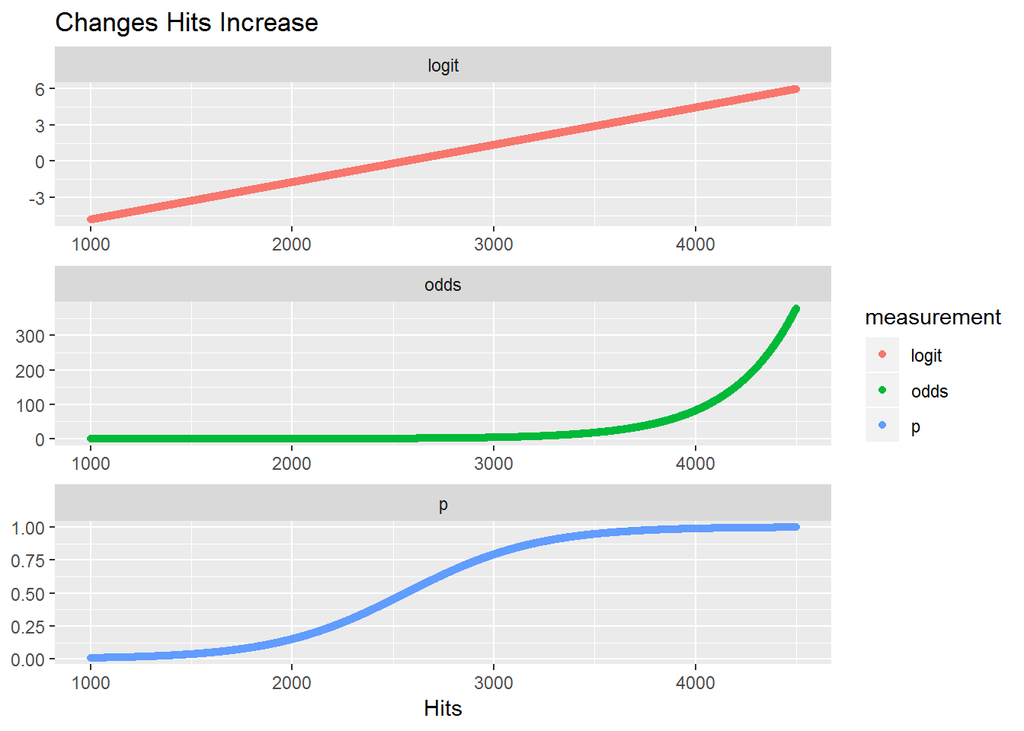

```r
mytibble = tibble(Hits = seq(1000,4500,1), logit = -7.8751981+0.0030698*Hits,odds = exp(logit), p = exp(-7.8751981+0.0030698*Hits)/(1+exp(-7.8751981+0.0030698*Hits))) %>%
  gather(measurement, value, -Hits)

mytibble %>%
  ggplot(aes(x=Hits,y=value, color = measurement)) +
  geom_point() +
  facet_wrap(~measurement, scales = "free", nrow = 3) +
  ggtitle("Changes Hits Increase") + ylab(NULL)
```

# Lets Recap Last Lesson (Lsn 5)

We learned that linear regression does not work for binary “yes/no” or “0/1” data for several reasons. Among them are:

- Meaningless interpretations of $\hat{\beta}$
- Meaningless predictions
- Insane Residual Plots

## Another view at what logistic regression is doing

Let’s take a look at our hall of fame data and aggregate our hits into bins. The table below shows bins for Career Hits and the proportion of players in that bin that were inducted into the Hall of Fame (recall that the expected value of a binary variable is the proportion of “1’s” or “responses”).

```r
estimatedprops = fulldata %>%
  select(H,HOF) %>%
  mutate(interval = cut_interval(H,length=250)) %>%
  group_by(interval, HOF) %>%
  summarise(n=n()) %>%
  mutate(freq = n/sum(n)) %>%
  filter(HOF==1) %>%
  ungroup() %>%
  mutate(Hits = seq(1250,1250+250*12,250))

estimatedprops
```

```
## # A tibble: 13 x 5
##    interval             HOF     n    freq  Hits
##    <fct>              <dbl> <int>   <dbl> <dbl>
##  1 [1e+03,1.25e+03]       1     1 0.00270  1250
##  2 (1.25e+03,1.5e+03]     1     8 0.0262   1500
##  3 (1.5e+03,1.75e+03]     1    12 0.0591   1750
##  4 (1.75e+03,2e+03]       1    13 0.0949   2000
##  5 (2e+03,2.25e+03]       1    26 0.232    2250
##  6 (2.25e+03,2.5e+03]     1    27 0.397    2500
##  7 (2.5e+03,2.75e+03]     1    23 0.511    2750
##  8 (2.75e+03,3e+03]       1    19 0.731    3000
##  9 (3e+03,3.25e+03]       1    13 0.812    3250
## 10 (3.25e+03,3.5e+03]     1     7 0.875    3500
## 11 (3.5e+03,3.75e+03]     1     2 1        3750
## 12 (3.75e+03,4e+03]       1     1 1        4000
## 13 (4e+03,4.25e+03]       1     1 1        4250
```

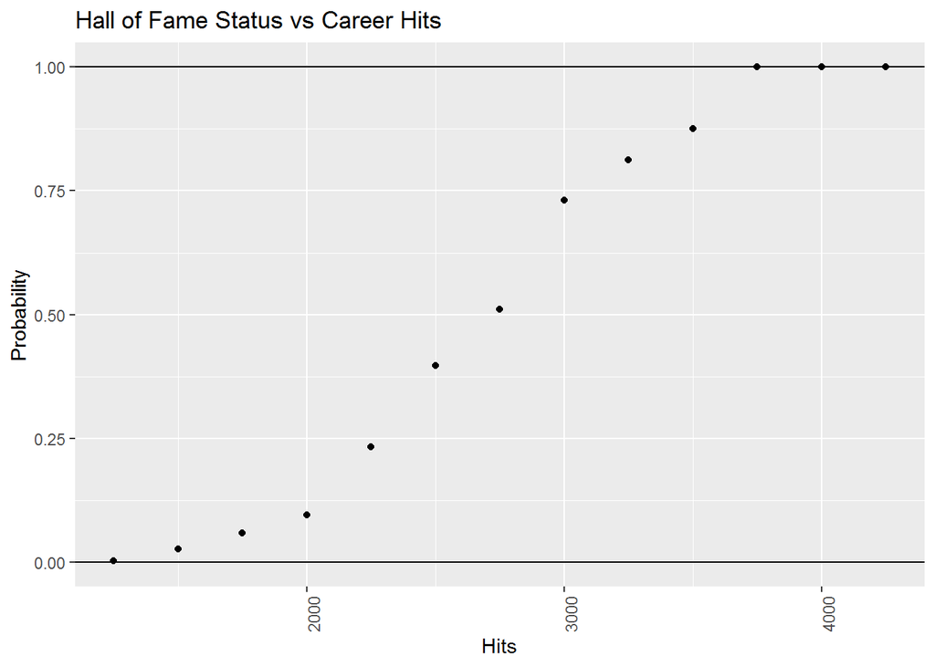

```r
estimatedprops %>%
  ggplot(aes(x = Hits, y = freq)) +
  geom_point() +
  geom_hline(yintercept=c(0,1)) +
  theme(axis.text.x = element_text(angle = 90, hjust = 1)) +
  ggtitle("Hall of Fame Status vs Career Hits") + ylab("Probability") + xlab("Hits")
```

So just a reminder:

The simple logistic regression model is $E(Y | X) = \pi(X) =\displaystyle \frac{e^{\beta_0+\beta_1 X}} {1+e^{\beta_0+ \beta_1 X}}$ where $Y$ is a binary response variable, $\pi(X)$ is the population proportion of responses for a given value of X, and $\beta_0$ and $\beta_1$ are regression parameters. A simple logistic regression function represents an “S-shaped” curve and has a maximum possible value of 1 and a minimum value of 0.

# Inference with Logistic Regression

As with linear regression, interest often lies in determining if the estimated regression parameters are sufficiently far from 0 to conclude that the true parameter value is not 0. Also as with logistic regression, slope parameters are often of the most interest although tests can be done on the intercept as well.

## The Wald test for regression parameters

Several tests exist to determine if the estimated parameters are sufficiently far from 0. The simplest and most often used is the Wald test. The steps of the Wald test are as follows.

Wald test for the slope parameter.

1. Set the null and alternative hypotheses
   $$H_0:\beta_1 = 0$$
   $$H_a:\beta_ 1 \ne 0$$
2. Find the test statistic.
   $$Z = \displaystyle \frac{b_1}{SE_{b_1}}$$
3. Find the p-value that corresponds to the test statistic. If $H_0$ is true, $Z \dot{\sim} N(0,1)$. ($Z$ is approximately (or more precisely, asymptotically) normally distributed)
4. Make a decision given a previously selected significance level, $\alpha$ (e.g. 0.05)
   - If the p-value is less than $\alpha$, sufficient evidence exists to reject the null hypothesis, $H_0$ in favor of the alternative hypothesis, $H_a$. Conclude that $\beta_1$ is significantly different from 0, which suggests that a statistically significant relationship exists between the predictor and binary response variables.
   - If the p-value is greater than or equal to $\alpha$, insufficient evidence exists to reject the null hypothesis, $H_0$ in favor of the alternative hypothesis, $H_a$. Conclude that $\beta_1$ is not significantly different from 0, which means no statistically significant relationship exists between the predictor and binary response variables.

The Wald Test for other model parameters are done in the same manner.

Note: Steps 2 and 3 are usually done using statistical software.

Very important note: When multiple predictors exist in a model, the conclusion is that a statistically significant relationship does (or does not) exists between the predictor and binary response variables *“controlling”* or *“adjusting”* for the other predictor variables.

Other very important note: due to the asymptotic nature of inference in logistic regression, sample size plays an important role. Unfortunately, determining if your sample is “large enough” is not as simple as it sounds. More to follow!

## Conducting a Wald Test and calculating Confidence Intervals in R

```r
logmod = glm(HOF~H, data = fulldata, family = binomial(link="logit"))
summary(logmod)
```

```
##
## Call:
## glm(formula = HOF ~ H, family = binomial(link = "logit"), data = fulldata)
##
## Deviance Residuals:
##     Min       1Q   Median       3Q      Max
## -3.2235  -0.3616  -0.2144  -0.1517   2.9409
##
## Coefficients:
##               Estimate Std. Error z value            Pr(>|z|)
## (Intercept) -7.8751981  0.4616943  -17.06 <0.0000000000000002 ***
## H            0.0030698  0.0002135   14.38 <0.0000000000000002 ***
## ---
## Signif. codes:  0 '***' 0.001 '**' 0.01 '*' 0.05 '.' 0.1 ' ' 1
##
## (Dispersion parameter for binomial family taken to be 1)
##
##     Null deviance: 940.73  on 1294  degrees of freedom
## Residual deviance: 605.56  on 1293  degrees of freedom
## AIC: 609.56
##
## Number of Fisher Scoring iterations: 6
```

In the above R output, the column labelled “z value” is the test statistic for the Wald test for that parameter. The column labelled “Pr(>|z|)” is the p-value.

```r
confint(logmod)
```

```
##                    2.5 %       97.5 %
## (Intercept) -8.822126880 -7.008943302
## H            0.002666544  0.003504946
```

confint.default() produces Wald confidence intervals for the regression parameters. The confidence level may be adjusted using the argument level = $(1-\alpha)$.

### How are we to interpret this confidence intervals?

A one unit increase in _____, yields a one unit increase in ______?

## Likelihood ratio tests

The Likelihood Ratio Test (LRT) compares two nested models, which means that all predictors in the smaller model are contained in the second, larger, model. This is similar to the Model Utility Test in Linear Regression.

The LRT for logistic regression.

1. Let model 1 contain $i$ predictors with parameters $\beta_0,\beta_1,\ldots,\beta_i$ and model 2 contain $i+ j$ predictors with parameters $\beta_0,\beta_1,\ldots,\beta_i, \beta_{i+1},\ldots,\beta_{i+j}$, where parameters $1,2,\ldots,i$ are the same in both models.
2. Set the null and alternative hypotheses:
   $$H_0:\beta_{i+1}=\ldots=\beta_{i+j}=0$$
   $H_a:$ at least one additional parameter $\beta_r \ne 0$ where $r \in i+1,\ldots,i+j$
3. Find the LR test statistic, G. The test is based on the ratio of likelihoods or difference in “Deviance” for the two models.
   - The deviance compares the likelihood of a model to the likelihood of a ``saturated’’ model (which contains as many parameters as data points). Specifically, the deviance is defined as:
     $$D = -2ln \displaystyle \frac{\text{likelihood of the fitted model}}{\text{likelihood of the saturated model}}$$
   - The deviance is analogous to the residual sum of squares in linear regression (in fact it *is* the residual sum of squares for linear regression).
   - $G=D($ model without variables $i+1,\ldots ,i+j)-D($ model with variables $i+1, \ldots i+j)$
4. Find the p-value that corresponds to the test statistic. Under $H_0$ G follows a Chi-square distribution with $j$ degrees of freedom (the number of additional predictors).
5. Make a decision given a previously selected significance level, $\alpha$ (e.g. 0.05)
   - If the p-value is less than $\alpha$, sufficient evidence exists to reject the null hypothesis, $H_0$ in favor of the alternative hypothesis, $H_a$. Conclude that at least one additional parameter is significantly different from 0.
   - If the p-value is greater than or equal to $\alpha$, insufficient evidence exists to reject the null hypothesis, $H_0$ in favor of the alternative hypothesis, $H_a$. Conclude that insufficient evidence exists between the binary response variable $Y$ and the additional variables corresponding to $\beta_{i+1},\ldots,\beta_{i+j}$, when controlling for the variables in the first model. In this case, the model with fewer predictors is typically preferred. (Failing to reject the null hypothesis using the LR test suggests that none of the additional variables in the second model are useful in predicting the response.)

Note: Steps 3 and 4 are usually accomplished using statistical software.

### Would adding `Runs`, “Help” our model?

Lets step through our hypothesis test:

Step 1:

Here is a reminder of our old model:

```r
logmod = glm(HOF~H, data = fulldata, family = binomial(link="logit"))
summary(logmod)
```

```
##
## Call:
## glm(formula = HOF ~ H, family = binomial(link = "logit"), data = fulldata)
##
## Deviance Residuals:
##     Min       1Q   Median       3Q      Max
## -3.2235  -0.3616  -0.2144  -0.1517   2.9409
##
## Coefficients:
##               Estimate Std. Error z value            Pr(>|z|)
## (Intercept) -7.8751981  0.4616943  -17.06 <0.0000000000000002 ***
## H            0.0030698  0.0002135   14.38 <0.0000000000000002 ***
## ---
## Signif. codes:  0 '***' 0.001 '**' 0.01 '*' 0.05 '.' 0.1 ' ' 1
##
## (Dispersion parameter for binomial family taken to be 1)
##
##     Null deviance: 940.73  on 1294  degrees of freedom
## Residual deviance: 605.56  on 1293  degrees of freedom
## AIC: 609.56
##
## Number of Fisher Scoring iterations: 6
```

Here is our new “saturated” model

```r
logmodsat = glm(HOF~H+R, data = fulldata, family = binomial(link="logit"))
summary(logmodsat)
```

```
##
## Call:
## glm(formula = HOF ~ H + R, family = binomial(link = "logit"),
##     data = fulldata)
##
## Deviance Residuals:
##     Min       1Q   Median       3Q      Max
## -3.1112  -0.3549  -0.2087  -0.1460   2.9307
##
## Coefficients:
##               Estimate Std. Error z value             Pr(>|z|)
## (Intercept) -7.8336267  0.4684487 -16.722 < 0.0000000000000002 ***
## H            0.0016071  0.0004074   3.945            0.0000797 ***
## R            0.0026908  0.0006664   4.038            0.0000539 ***
## ---
## Signif. codes:  0 '***' 0.001 '**' 0.01 '*' 0.05 '.' 0.1 ' ' 1
##
## (Dispersion parameter for binomial family taken to be 1)
##
##     Null deviance: 940.73  on 1294  degrees of freedom
## Residual deviance: 588.90  on 1292  degrees of freedom
## AIC: 594.9
##
## Number of Fisher Scoring iterations: 6
```

Step 2:

$H_0:\beta_{i+1}=\ldots=\beta_{i+j}=0$

$H_a:$ at least one additional parameter $\beta_r \ne 0$ where $r \in i+1,\ldots,i+j$

Step3:

Smaller model deviance and residual

```r
smaller = summary(logmod)
smaller$deviance
```

```
## [1] 605.5595
```

```r
smaller$df.residual
```

```
## [1] 1293
```

Larger model deviance and residual

```r
larger = summary(logmodsat)
larger$deviance
```

```
## [1] 588.8963
```

```r
larger$df.residual
```

```
## [1] 1292
```

Difference in deviance and residuals

```r
smaller$deviance - larger$deviance
```

```
## [1] 16.6632
```

```r
smaller$df.residual - larger$df.residual
```

```
## [1] 1
```

Step 4:

Find P Value

```r
1-pchisq(smaller$deviance - larger$deviance, smaller$df.residual - larger$df.residual )
```

```
## [1] 0.00004463868
```

Step 5: Make decision. In this case: Reject the Null Hypothesis

Or maybe more simply…

```r
anova(logmod,logmodsat, test = "Chisq")
```

```
## Analysis of Deviance Table
##
## Model 1: HOF ~ H
## Model 2: HOF ~ H + R
##   Resid. Df Resid. Dev Df Deviance   Pr(>Chi)
## 1      1293     605.56
## 2      1292     588.90  1   16.663 0.00004464 ***
## ---
## Signif. codes:  0 '***' 0.001 '**' 0.01 '*' 0.05 '.' 0.1 ' ' 1
```

## AIC

The AIC (Akaike Information Criteria) is a measure used to compare models with a different number of parameters. The AIC is computed as $AIC=D+2(p+1)$, where…

- $D$ is the deviance and
- $p$ is the number of variables in the model.

A small $D$ and, therefore, a small $AIC$ is preferred. The second term in the AIC, $2(p+1)$, acts as a “penalty” for adding predictors to the model by increasing the AIC. AIC attempts to avoid “overfitting” the model with variables that do not contribute to successful prediction. An advantage is that AIC can compare two models that are not nested.

The AIC is printed when the summary() command is called. We have already saved these summaries.

```r
smaller$aic
```

```
## [1] 609.5595
```

```r
larger$aic
```

```
## [1] 594.8963
```

In this case, I certainly like the larger model.

## Another look with other data

First fit the smaller model.

```r
FG.dat = read.csv("2012 FG attempts.csv")
FG.dat$fourth = ifelse(FG.dat$Quarter==4,1,0)
FG.mod1 = glm(FG.dat$Outcome~FG.dat$Distance, family = binomial)
summary(FG.mod1)
```

```
##
## Call:
## glm(formula = FG.dat$Outcome ~ FG.dat$Distance, family = binomial)
##
## Deviance Residuals:
##     Min       1Q   Median       3Q      Max
## -2.6957   0.2070   0.3598   0.6127   1.2259
##
## Coefficients:
##                 Estimate Std. Error z value            Pr(>|z|)
## (Intercept)      6.42488    0.60315   10.65 <0.0000000000000002 ***
## FG.dat$Distance -0.11273    0.01331   -8.47 <0.0000000000000002 ***
## ---
## Signif. codes:  0 '***' 0.001 '**' 0.01 '*' 0.05 '.' 0.1 ' ' 1
##
## (Dispersion parameter for binomial family taken to be 1)
##
##     Null deviance: 650.53  on 773  degrees of freedom
## Residual deviance: 550.81  on 772  degrees of freedom
## AIC: 554.81
##
## Number of Fisher Scoring iterations: 5
```

Then fit the larger model

```r
FG.mod2 = glm(FG.dat$Outcome~FG.dat$Distance+FG.dat$fourth, family = binomial)
summary(FG.mod2)
```

```
##
## Call:
## glm(formula = FG.dat$Outcome ~ FG.dat$Distance + FG.dat$fourth,
##     family = binomial)
##
## Deviance Residuals:
##     Min       1Q   Median       3Q      Max
## -2.6577   0.2082   0.3575   0.6071   1.2610
##
## Coefficients:
##                 Estimate Std. Error z value            Pr(>|z|)
## (Intercept)      6.30245    0.60738  10.377 <0.0000000000000002 ***
## FG.dat$Distance -0.11201    0.01333  -8.406 <0.0000000000000002 ***
## FG.dat$fourth    0.38118    0.26349   1.447               0.148
## ---
## Signif. codes:  0 '***' 0.001 '**' 0.01 '*' 0.05 '.' 0.1 ' ' 1
##
## (Dispersion parameter for binomial family taken to be 1)
##
##     Null deviance: 650.53  on 773  degrees of freedom
## Residual deviance: 548.63  on 771  degrees of freedom
## AIC: 554.63
##
## Number of Fisher Scoring iterations: 5
```

Use the anova() command to conduct the LRT. The smaller model must be listed first.

```r
anova(FG.mod1, FG.mod2, test="Chisq")
```

```
## Analysis of Deviance Table
##
## Model 1: FG.dat$Outcome ~ FG.dat$Distance
## Model 2: FG.dat$Outcome ~ FG.dat$Distance + FG.dat$fourth
##   Resid. Df Resid. Dev Df Deviance Pr(>Chi)
## 1       772     550.81
## 2       771     548.63  1   2.1836   0.1395
```

The output lists the degrees of freedom and residual deviance for each model. `Pr(>Chi)' gives the p-value from the Chi-square test. In this case a p-value of 0.1395 indicates that adding`fourth’ to the model does not help predict `Outcome’.

### AIC

The AIC is printed when the summary() command is called.

```r
summary(FG.mod1)
```

```
##
## Call:
## glm(formula = FG.dat$Outcome ~ FG.dat$Distance, family = binomial)
##
## Deviance Residuals:
##     Min       1Q   Median       3Q      Max
## -2.6957   0.2070   0.3598   0.6127   1.2259
##
## Coefficients:
##                 Estimate Std. Error z value            Pr(>|z|)
## (Intercept)      6.42488    0.60315   10.65 <0.0000000000000002 ***
## FG.dat$Distance -0.11273    0.01331   -8.47 <0.0000000000000002 ***
## ---
## Signif. codes:  0 '***' 0.001 '**' 0.01 '*' 0.05 '.' 0.1 ' ' 1
##
## (Dispersion parameter for binomial family taken to be 1)
##
##     Null deviance: 650.53  on 773  degrees of freedom
## Residual deviance: 550.81  on 772  degrees of freedom
## AIC: 554.81
##
## Number of Fisher Scoring iterations: 5
```

```r
summary(FG.mod2)
```

```
##
## Call:
## glm(formula = FG.dat$Outcome ~ FG.dat$Distance + FG.dat$fourth,
##     family = binomial)
##
## Deviance Residuals:
##     Min       1Q   Median       3Q      Max
## -2.6577   0.2082   0.3575   0.6071   1.2610
##
## Coefficients:
##                 Estimate Std. Error z value            Pr(>|z|)
## (Intercept)      6.30245    0.60738  10.377 <0.0000000000000002 ***
## FG.dat$Distance -0.11201    0.01333  -8.406 <0.0000000000000002 ***
## FG.dat$fourth    0.38118    0.26349   1.447               0.148
## ---
## Signif. codes:  0 '***' 0.001 '**' 0.01 '*' 0.05 '.' 0.1 ' ' 1
##
## (Dispersion parameter for binomial family taken to be 1)
##
##     Null deviance: 650.53  on 773  degrees of freedom
## Residual deviance: 548.63  on 771  degrees of freedom
## AIC: 554.63
##
## Number of Fisher Scoring iterations: 5
```

The AIC for model 1 is slightly higher but only by 0.18. In this case, I would consider using the smaller model.

# Purposeful selection (Lsn 6)

Purposeful selection is one strategy for model building. It is more time consuming (and less automated) than stepwise selection, especially as the number of predictor variables increases. But I find that I like the more methodical approach. (This description is modified from the approach described in *Applied Logistic Regression, 3rd Edition* by Hosmer, Lemeshow and Sturdivant.)

1. Start with a univariate analysis of each predictor variable. e.g. fit the univariable regression model to obtain the estimated coefficient, it’s standard error and the LR and/or Wald test. Identify as candidates for an initial multivariable model, any variable whose univariable test has a p-value less than 0.25.
2. Fit a multivariable model containing all variables identified in Step 1. Assess the importance of each variable using the p-value of the corresponding Wald test. Eliminate any variables that do not contribute to the model (p-values below 0.05). (I recommend doing this one at a time where possible.) Use a LRT to compare the smaller and larger models. (Beware of missing data - ensure each model is fit using the same sample.)
3. Compare the coefficients in the reduced model to their respective values in the larger model. A coefficient that changes by more than 20% indicates that one of the excluded variables is important in the sens of adjusting the effects of the remaining variables; it should be added back to the model. Iterate through steps 2 and 3 until you have a model that doesn’t change.
4. Add each variable not identified in step 1 to the model one at a time and check its significance. The model at the end of this step is the *preliminary main effects model*.
5. Examine the variables in the preliminary main effects model. Are the categories of categorical variables appropriately defined? Are the continuous variables linear in the logit (more to follow on how to check). The model at the end of this step is the *main effects model*.
6. Check for interactions among variables in the main effects model. Add interactions, one at a time, to the main effects model. Include only interaction terms that are both clinically plausible and statistically significant (typically a the 0.1 level). Remove insignificant interactions as in step 2.
7. Assess the adequacy and fit of the model in step 6.

## Purposeful Selection Example

Step 1: Start with a univariate analysis of each predictor variable. e.g. fit the univariable regression model to obtain the estimated coefficient, it’s standard error and the LR and/or Wald test. Identify as candidates for an initial multivariable model, any variable whose univariable test has a p-value less than 0.25.

Hits

```r
summary(glm(HOF~H, data = fulldata, family = binomial(link="logit")))
```

```
##
## Call:
## glm(formula = HOF ~ H, family = binomial(link = "logit"), data = fulldata)
##
## Deviance Residuals:
##     Min       1Q   Median       3Q      Max
## -3.2235  -0.3616  -0.2144  -0.1517   2.9409
##
## Coefficients:
##               Estimate Std. Error z value            Pr(>|z|)
## (Intercept) -7.8751981  0.4616943  -17.06 <0.0000000000000002 ***
## H            0.0030698  0.0002135   14.38 <0.0000000000000002 ***
## ---
## Signif. codes:  0 '***' 0.001 '**' 0.01 '*' 0.05 '.' 0.1 ' ' 1
##
## (Dispersion parameter for binomial family taken to be 1)
##
##     Null deviance: 940.73  on 1294  degrees of freedom
## Residual deviance: 605.56  on 1293  degrees of freedom
## AIC: 609.56
##
## Number of Fisher Scoring iterations: 6
```

Candidate

Runs

```r
summary(glm(HOF~R, data = fulldata, family = binomial(link="logit")))
```

```
##
## Call:
## glm(formula = HOF ~ R, family = binomial(link = "logit"), data = fulldata)
##
## Deviance Residuals:
##     Min       1Q   Median       3Q      Max
## -2.8488  -0.3628  -0.2232  -0.1575   2.9088
##
## Coefficients:
##               Estimate Std. Error z value            Pr(>|z|)
## (Intercept) -7.1164716  0.4094774  -17.38 <0.0000000000000002 ***
## R            0.0050098  0.0003497   14.32 <0.0000000000000002 ***
## ---
## Signif. codes:  0 '***' 0.001 '**' 0.01 '*' 0.05 '.' 0.1 ' ' 1
##
## (Dispersion parameter for binomial family taken to be 1)
##
##     Null deviance: 940.73  on 1294  degrees of freedom
## Residual deviance: 604.95  on 1293  degrees of freedom
## AIC: 608.95
##
## Number of Fisher Scoring iterations: 6
```

Candidate

At Bats

```r
summary(glm(HOF~AB, data = fulldata, family = binomial(link="logit")))
```

```
##
## Call:
## glm(formula = HOF ~ AB, family = binomial(link = "logit"), data = fulldata)
##
## Deviance Residuals:
##     Min       1Q   Median       3Q      Max
## -2.8957  -0.4093  -0.2582  -0.1846   2.8401
##
## Coefficients:
##                Estimate  Std. Error z value            Pr(>|z|)
## (Intercept) -7.51323435  0.45094753  -16.66 <0.0000000000000002 ***
## AB           0.00083189  0.00006084   13.67 <0.0000000000000002 ***
## ---
## Signif. codes:  0 '***' 0.001 '**' 0.01 '*' 0.05 '.' 0.1 ' ' 1
##
## (Dispersion parameter for binomial family taken to be 1)
##
##     Null deviance: 940.73  on 1294  degrees of freedom
## Residual deviance: 677.33  on 1293  degrees of freedom
## AIC: 681.33
##
## Number of Fisher Scoring iterations: 6
```

Games

Candidate

```r
summary(glm(HOF~G, data = fulldata, family = binomial(link="logit")))
```

```
##
## Call:
## glm(formula = HOF ~ G, family = binomial(link = "logit"), data = fulldata)
##
## Deviance Residuals:
##     Min       1Q   Median       3Q      Max
## -2.5056  -0.4394  -0.2825  -0.2041   2.7714
##
## Coefficients:
##               Estimate Std. Error z value            Pr(>|z|)
## (Intercept) -7.3795100  0.4551933  -16.21 <0.0000000000000002 ***
## G            0.0029406  0.0002248   13.08 <0.0000000000000002 ***
## ---
## Signif. codes:  0 '***' 0.001 '**' 0.01 '*' 0.05 '.' 0.1 ' ' 1
##
## (Dispersion parameter for binomial family taken to be 1)
##
##     Null deviance: 940.73  on 1294  degrees of freedom
## Residual deviance: 713.55  on 1293  degrees of freedom
## AIC: 717.55
##
## Number of Fisher Scoring iterations: 6
```

Step 2: Fit a multivariable model containing all variables identified in Step 1. Assess the importance of each variable using the p-value of the corresponding Wald test. Eliminate any variables that do not contribute to the model (p-values below 0.05). (I recommend doing this one at a time where possible.) Use a LRT to compare the smaller and larger models. (Beware of missing data - ensure each model is fit using the same sample.)

```r
full.mod = glm(HOF~H+R+AB+G, data = fulldata, family = binomial(link="logit"))
summary(full.mod)
```

```
##
## Call:
## glm(formula = HOF ~ H + R + AB + G, family = binomial(link = "logit"),
##     data = fulldata)
##
## Deviance Residuals:
##     Min       1Q   Median       3Q      Max
## -3.0336  -0.3325  -0.2019  -0.1419   2.9891
##
## Coefficients:
##               Estimate Std. Error z value             Pr(>|z|)
## (Intercept) -6.9587943  0.5069193 -13.728 < 0.0000000000000002 ***
## H            0.0064405  0.0009697   6.642       0.000000000031 ***
## R            0.0027910  0.0007321   3.812             0.000138 ***
## AB          -0.0018592  0.0004438  -4.190       0.000027949115 ***
## G            0.0011857  0.0010328   1.148             0.250943
## ---
## Signif. codes:  0 '***' 0.001 '**' 0.01 '*' 0.05 '.' 0.1 ' ' 1
##
## (Dispersion parameter for binomial family taken to be 1)
##
##     Null deviance: 940.73  on 1294  degrees of freedom
## Residual deviance: 550.61  on 1290  degrees of freedom
## AIC: 560.61
##
## Number of Fisher Scoring iterations: 6
```

```r
red.mod.1 = glm(HOF~H+R+AB, data = fulldata, family = binomial(link="logit"))
summary(red.mod.1)
```

```
##
## Call:
## glm(formula = HOF ~ H + R + AB, family = binomial(link = "logit"),
##     data = fulldata)
##
## Deviance Residuals:
##     Min       1Q   Median       3Q      Max
## -3.0788  -0.3316  -0.2002  -0.1398   3.0711
##
## Coefficients:
##               Estimate Std. Error z value             Pr(>|z|)
## (Intercept) -6.8274204  0.4902975 -13.925 < 0.0000000000000002 ***
## H            0.0061507  0.0009276   6.631      0.0000000000333 ***
## R            0.0026520  0.0007117   3.726             0.000194 ***
## AB          -0.0014489  0.0002556  -5.668      0.0000000144844 ***
## ---
## Signif. codes:  0 '***' 0.001 '**' 0.01 '*' 0.05 '.' 0.1 ' ' 1
##
## (Dispersion parameter for binomial family taken to be 1)
##
##     Null deviance: 940.73  on 1294  degrees of freedom
## Residual deviance: 551.91  on 1291  degrees of freedom
## AIC: 559.91
##
## Number of Fisher Scoring iterations: 6
```

```r
anova(red.mod.1,full.mod, test = "Chisq")
```

```
## Analysis of Deviance Table
##
## Model 1: HOF ~ H + R + AB
## Model 2: HOF ~ H + R + AB + G
##   Resid. Df Resid. Dev Df Deviance Pr(>Chi)
## 1      1291     551.91
## 2      1290     550.61  1    1.306   0.2531
```

Since there is no “significant difference” between these models, we’ll go with the most parsimonious model.

Step 3: Compare the coefficients in the reduced model to their respective values in the larger model. A coefficient that changes by more than 20% indicates that one of the excluded variables is important in the sens of adjusting the effects of the remaining variables; it should be added back to the model. Iterate through steps 2 and 3 until you have a model that doesn’t change.

Delta Beta Hat Test $\Delta \hat{\beta}$ test

```r
dbhat = (full.mod$coefficients[2] - red.mod.1$coefficients[2])/full.mod$coefficients[2]
dbhat
```

```
##          H
## 0.04499373
```

As you see below, $\Delta \hat{\beta} < .2$

```r
.2 > abs(dbhat)
```

```
##    H
## TRUE
```

Step 4: Add each variable not identified in step 1 to the model one at a time and check its significance. The model at the end of this step is the *preliminary main effects model*.

```r
prelim.me.mod = glm(HOF~H+R+AB, data = fulldata, family = binomial(link="logit"))
summary(prelim.me.mod)
```

```
##
## Call:
## glm(formula = HOF ~ H + R + AB, family = binomial(link = "logit"),
##     data = fulldata)
##
## Deviance Residuals:
##     Min       1Q   Median       3Q      Max
## -3.0788  -0.3316  -0.2002  -0.1398   3.0711
##
## Coefficients:
##               Estimate Std. Error z value             Pr(>|z|)
## (Intercept) -6.8274204  0.4902975 -13.925 < 0.0000000000000002 ***
## H            0.0061507  0.0009276   6.631      0.0000000000333 ***
## R            0.0026520  0.0007117   3.726             0.000194 ***
## AB          -0.0014489  0.0002556  -5.668      0.0000000144844 ***
## ---
## Signif. codes:  0 '***' 0.001 '**' 0.01 '*' 0.05 '.' 0.1 ' ' 1
##
## (Dispersion parameter for binomial family taken to be 1)
##
##     Null deviance: 940.73  on 1294  degrees of freedom
## Residual deviance: 551.91  on 1291  degrees of freedom
## AIC: 559.91
##
## Number of Fisher Scoring iterations: 6
```

Complete

Step 5: Examine the variables in the preliminary main effects model. Are the categories of categorical variables appropriately defined? Are the continuous variables linear in the logit (more to follow on how to check). The model at the end of this step is the *main effects model*.

More to follow

Step 6: Check for interactions among variables in the main effects model. Add interactions, one at a time, to the main effects model. Include only interaction terms that are both clinically plausible and statistically significant (typically a the 0.1 level). Remove insignificant interactions as in step 2.

(Assess the importance of each variable using the p-value of the corresponding Wald test. Eliminate any variables that do not contribute to the model (p-values below 0.05). Use a LRT to compare the smaller and larger models. )

Add the Hits/Runs interaction

```r
prelim.me.mod.1 = glm(HOF~H+R+AB+H*R, data = fulldata, family = binomial(link="logit"))
summary(prelim.me.mod.1)
```

```
##
## Call:
## glm(formula = HOF ~ H + R + AB + H * R, family = binomial(link = "logit"),
##     data = fulldata)
##
## Deviance Residuals:
##     Min       1Q   Median       3Q      Max
## -1.9403  -0.3236  -0.1554  -0.0902   3.2752
##
## Coefficients:
##                  Estimate    Std. Error z value           Pr(>|z|)
## (Intercept) -11.296296789   1.454876856  -7.764 0.0000000000000082 ***
## H             0.008296566   0.001103469   7.519 0.0000000000000554 ***
## R             0.006790928   0.001368623   4.962 0.0000006981750589 ***
## AB           -0.001447940   0.000246361  -5.877 0.0000000041697138 ***
## H:R          -0.000001888   0.000000524  -3.604           0.000313 ***
## ---
## Signif. codes:  0 '***' 0.001 '**' 0.01 '*' 0.05 '.' 0.1 ' ' 1
##
## (Dispersion parameter for binomial family taken to be 1)
##
##     Null deviance: 940.73  on 1294  degrees of freedom
## Residual deviance: 540.36  on 1290  degrees of freedom
## AIC: 550.36
##
## Number of Fisher Scoring iterations: 7
```

Now for the LR test.

```r
anova(prelim.me.mod,prelim.me.mod.1, test = "Chisq")
```

```
## Analysis of Deviance Table
##
## Model 1: HOF ~ H + R + AB
## Model 2: HOF ~ H + R + AB + H * R
##   Resid. Df Resid. Dev Df Deviance  Pr(>Chi)
## 1      1291     551.91
## 2      1290     540.36  1   11.555 0.0006757 ***
## ---
## Signif. codes:  0 '***' 0.001 '**' 0.01 '*' 0.05 '.' 0.1 ' ' 1
```

Add the Hits/At Bats Interaction

```r
prelim.me.mod.2 = glm(HOF~H+R+AB+H*R+H*AB, data = fulldata, family = binomial(link="logit"))
summary(prelim.me.mod.2)
```

```
##
## Call:
## glm(formula = HOF ~ H + R + AB + H * R + H * AB, family = binomial(link = "logit"),
##     data = fulldata)
##
## Deviance Residuals:
##     Min       1Q   Median       3Q      Max
## -2.0704  -0.3236  -0.1528  -0.0870   3.3745
##
## Coefficients:
##                   Estimate     Std. Error z value         Pr(>|z|)
## (Intercept) -10.2972470712   1.6261753399  -6.332 0.00000000024171 ***
## H             0.0078565022   0.0011508626   6.827 0.00000000000869 ***
## R             0.0104401782   0.0027944177   3.736         0.000187 ***
## AB           -0.0021796738   0.0005510706  -3.955 0.00007642461817 ***
## H:R          -0.0000035007   0.0000011901  -2.942         0.003265 **
## H:AB          0.0000003204   0.0000002151   1.489         0.136437
## ---
## Signif. codes:  0 '***' 0.001 '**' 0.01 '*' 0.05 '.' 0.1 ' ' 1
##
## (Dispersion parameter for binomial family taken to be 1)
##
##     Null deviance: 940.73  on 1294  degrees of freedom
## Residual deviance: 538.17  on 1289  degrees of freedom
## AIC: 550.17
##
## Number of Fisher Scoring iterations: 7
```

Remove

Add the Runs/At Bats Interactions

```r
prelim.me.mod.3 = glm(HOF~H+R+AB+H*R+R*AB, data = fulldata, family = binomial(link="logit"))
summary(prelim.me.mod.3)
```

```
##
## Call:
## glm(formula = HOF ~ H + R + AB + H * R + R * AB, family = binomial(link = "logit"),
##     data = fulldata)
##
## Deviance Residuals:
##     Min       1Q   Median       3Q      Max
## -1.8999  -0.3186  -0.1502  -0.0848   3.4022
##
## Coefficients:
##                   Estimate     Std. Error z value         Pr(>|z|)
## (Intercept) -10.4444693757   1.5264167213  -6.842 0.00000000000778 ***
## H             0.0129888836   0.0030271499   4.291 0.00001780335500 ***
## R             0.0060564557   0.0014158993   4.277 0.00001890359379 ***
## AB           -0.0029353051   0.0009359372  -3.136          0.00171 **
## H:R          -0.0000054625   0.0000021478  -2.543          0.01098 *
## R:AB          0.0000011431   0.0000006809   1.679          0.09317 .
## ---
## Signif. codes:  0 '***' 0.001 '**' 0.01 '*' 0.05 '.' 0.1 ' ' 1
##
## (Dispersion parameter for binomial family taken to be 1)
##
##     Null deviance: 940.73  on 1294  degrees of freedom
## Residual deviance: 537.82  on 1289  degrees of freedom
## AIC: 549.82
##
## Number of Fisher Scoring iterations: 7
```

Maybe, lets do the LR Test

```r
anova(prelim.me.mod.1,prelim.me.mod.3, test = "Chisq")
```

```
## Analysis of Deviance Table
##
## Model 1: HOF ~ H + R + AB + H * R
## Model 2: HOF ~ H + R + AB + H * R + R * AB
##   Resid. Df Resid. Dev Df Deviance Pr(>Chi)
## 1      1290     540.36
## 2      1289     537.82  1   2.5358   0.1113
```

No difference, so do not use the more complicated model.

Now, just for the heck of it.

```r
prelim.me.mod.4 = glm(HOF~H+R+AB+R*AB, data = fulldata, family = binomial(link="logit"))
summary(prelim.me.mod.4)
```

```
##
## Call:
## glm(formula = HOF ~ H + R + AB + R * AB, family = binomial(link = "logit"),
##     data = fulldata)
##
## Deviance Residuals:
##     Min       1Q   Median       3Q      Max
## -2.0772  -0.3309  -0.1672  -0.0993   3.1877
##
## Coefficients:
##                   Estimate     Std. Error z value          Pr(>|z|)
## (Intercept) -10.9825056004   1.5353331502  -7.153 0.000000000000848 ***
## H             0.0059091814   0.0008985313   6.576 0.000000000048169 ***
## R             0.0065054386   0.0014573835   4.464 0.000008052638319 ***
## AB           -0.0007973257   0.0003257364  -2.448            0.0144 *
## R:AB         -0.0000005129   0.0000001660  -3.090            0.0020 **
## ---
## Signif. codes:  0 '***' 0.001 '**' 0.01 '*' 0.05 '.' 0.1 ' ' 1
##
## (Dispersion parameter for binomial family taken to be 1)
##
##     Null deviance: 940.73  on 1294  degrees of freedom
## Residual deviance: 543.16  on 1290  degrees of freedom
## AIC: 553.16
##
## Number of Fisher Scoring iterations: 7
```

Why do this? And why am I not doing a LR test?

Step 7: Assess the adequacy and fit of the model in step 6.

speaking of step 7….

# Assessing Model Adequacy

## Residuals

As mentioned before, the logistic regression error, $\epsilon$, is the difference between the binary response value and the probability from the logistic regression function, $Y-\pi(X)$. A sample residual, $e_i$, estimates the error; $e_i = Y_i-\hat{\pi}(X_i)$. Since $Y$ is a binary response, only two residual values are possible for each value of $X$ (either $1-\hat{\pi}(X_i)$ or $-\hat{\pi}(X_i)$. Pearson residuals (also called standardized residuals) scale the residuals by dividing by the estimated standard deviation. This can make it easier to identify unusual observations. Plotting residuals against the fitted values can help identify poorly fit observations.

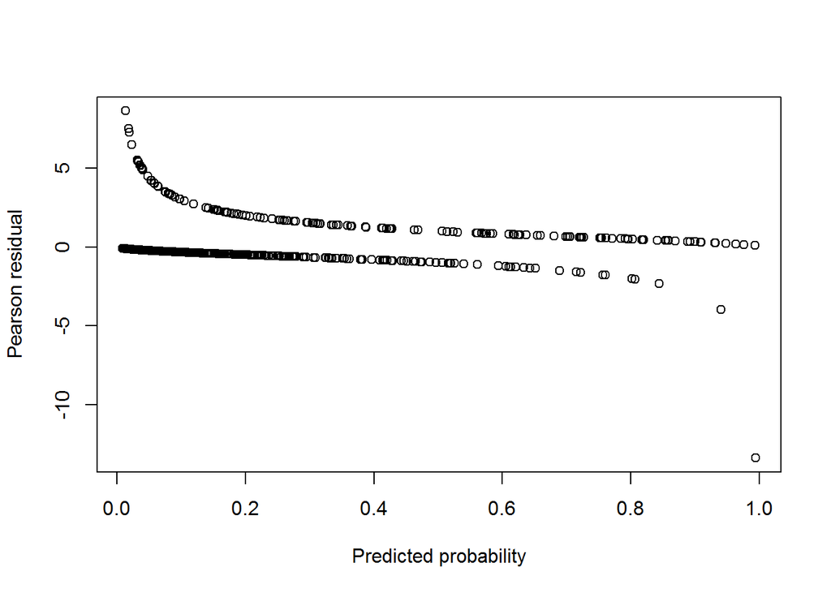

```r
mod.hit = glm(HOF ~ H, family = binomial, data = fulldata)
pihat = mod.hit$fitted.values
Presids = residuals(mod.hit, type = "pearson")
plot(pihat, Presids, xlab = "Predicted probability", ylab = "Pearson residual")
```

The two curves are for $Y = 0$ and $Y = 1$. (Which is which?)

## Hosmer-Lemeshow goodness of fit (GOF) test

Residual plots provide information about poor predictions. The Hosmer-Lemeshow goodness of fit (GOF) test assesses whether the model predictions in general are close to the observed values of $Y$. The test groups the observations based on predicted probabilities. For a given group, the expected number of values with $Y=1$ is compared to the observed number (this should sound a lot like a chi-squared goodness of fit test). The null hypothesis of the test is that the model fits the data well. The test statistic measures the differences in observed and expected values. A poorly fit model results in a large test statistic, which results in rejecting the null hypothesis.

1. Set the null and alternative hypotheses
- $H_0$:the model fits the data
- $H_a$: the model does not fit the data
2. Find the test statistic $C = \sum \displaystyle \frac{\text{(observed count - expected count)}^2}{\text{expected count}}$

More Specifically:

$$\hat{C} = \sum_{k=1}^{g} \bigg[ \frac{(o_{1k}-\hat{e}_{1k})^2}{\hat{e}_{1k}}+\frac{(o_{0k}-\hat{e}_{0k})^2}{\hat{e}_{0k}} \bigg]$$
where

$k$ is the number of $g$ groups you divide your data into of roughly equal size;

$o_{1k}$ and $o_{0k}$ is the number of observed successes and failures (respectivly) observed in the kth group and;

$\hat{e}_{1k}$ and $\hat{e}_{0k}$ are the expected number of successes and failures (respectively) in the kth group.

$\hat{e}_{1k}$ is calculated by:

$$\hat{e}_{1k} = \sum_{j=1}^{c_k}m_j\hat{\pi_j}$$

and $\hat{e}_{0k}$ is calculated by:

$$\hat{e}_{0k} = \sum_{j=1}^{c_k}m_j(1-\hat{\pi_j})$$
where $m_j$ is the jth observation of group k and $\hat{\pi_j}$ is the estimated probability of success of the jth observation.

3. Find the p-value that corresponds to the test statistic. Under $H_0$, C follows a Chi-square distribution, $C \sim \chi^2_{G-2}$ where G is the number of groups the observations were grouped into.
4. Make a decision given a previously selected significance level, $\alpha$ (e.g. 0.05)
   - If the p-value is less than $\alpha$, sufficient evidence exists to reject the null hypothesis, $H_0$ in favor of the alternative hypothesis, $H_a$. Conclude that evidence of poor model fit exists.
   - If the p-value is greater than or equal to $\alpha$, insufficient evidence exists to reject the null hypothesis, $H_0$ in favor of the alternative hypothesis, $H_a$. Conclude that insufficient evidence exists to suggest poor model fit.

Note: Steps 2 and 3 are usually accomplished using statistical software.

```r
library(ResourceSelection)
```

```
## ResourceSelection 0.3-2   2017-02-28
```

```r
hl = hoslem.test(mod.hit$y, fitted(mod.hit), g=10)
hl$observed
```

```
##
## cutyhat             y0  y1
##   [0.00814,0.0108] 132   0
##   (0.0108,0.0136]  130   1
##   (0.0136,0.018]   126   1
##   (0.018,0.0238]   127   2
##   (0.0238,0.0342]  126   3
##   (0.0342,0.0489]  122   7
##   (0.0489,0.0846]  118  11
##   (0.0846,0.166]   118  13
##   (0.166,0.358]     93  36
##   (0.358,0.994]     50  79
```

```r
hl$expected
```

```
##
## cutyhat                 yhat0      yhat1
##   [0.00814,0.0108] 130.768407   1.231593
##   (0.0108,0.0136]  129.412225   1.587775
##   (0.0136,0.018]   124.991497   2.008503
##   (0.018,0.0238]   126.312608   2.687392
##   (0.0238,0.0342]  125.293712   3.706288
##   (0.0342,0.0489]  123.695404   5.304596
##   (0.0489,0.0846]  120.644405   8.355595
##   (0.0846,0.166]   115.111707  15.888293
##   (0.166,0.358]     97.551754  31.448246
##   (0.358,0.994]     48.218280  80.781720
```

```r
hl
```

```
##
##  Hosmer and Lemeshow goodness of fit (GOF) test
##
## data:  mod.hit$y, fitted(mod.hit)
## X-squared = 5.3299, df = 8, p-value = 0.7218
```

## Influential observations

Individual observations with a high influence can affect the estimated model parameters. An observation is influential if the presence of such an observation impacts the overall model fit or parameter estimate. An influential observation either is an outlier, has a high leverage, or both.

- An *outlier* is an observation in a logistic regression analysis that has an extreme residual. Residual plots covered in a previous section are useful in identifying outliers.
- A *high leverage observation* is an observation that has an unusual combination of predictor values. You can think of this as an outlier in the horizontal direction. A high leverage observation can “pull” the estimated logistic function towards itself.
  - Leverage is commonly denoted by $h_i$ and can easily be produced in R. A plot of the leverages versus the predicted probabilities helps identify observations of possible concern.

Influence statistics that are functions of residual and leverage values are useful in determining influential observations. Several influence statistics have been developed for logistic regression. Cook’s Distance is a commonly used metric; it indicates how much an observation is likely to change the parameter estimates.

The formula for Cook’s Distance is $\Delta\hat{\beta}_i = \displaystyle \frac{h_i (r^p_i)^2}{(1-h_i)^2}$, where $r^p_i$ is the Pearson residual and $h_i$ is the leverage for observation $i$.

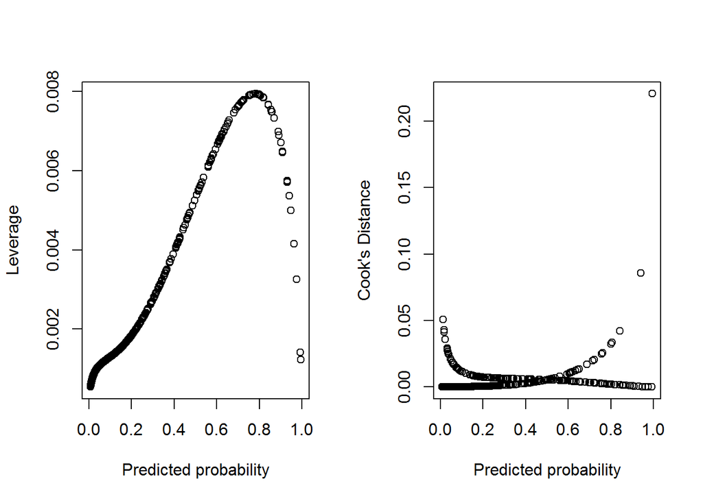

```r
pihat = mod.hit$fitted.values #estimated probablilities from the logistic regression model
h = hatvalues(mod.hit) #leverage
par(mfrow = c(1,2)) #make two plots appear side by side
plot(pihat, h, xlab = "Predicted probability", ylab = "Leverage")
Presids = residuals(mod.hit, type = "pearson") #pearsob residuals
cook =  h*Presids^2 / ((1-h)^2) #calculate cook's distance
plot(pihat, cook, xlab = "Predicted probability", ylab = "Cook's Distance")
```

```r
par(mfrow = c(1,1))
```

## Linear in the logit

We have seen the logistic regression model written as $E(Y | X) = \pi(X) =\displaystyle \frac{e^{\beta_0+\beta_1 X}} {1+e^{\beta_0+ \beta_1 X}}$. Equivalently, we can write it as $g(X) = ln ( \frac{\pi(X)}{1 - \pi(X)} ) = \beta_0 + \beta_1 X$. The function on the left hand side of the equation is called the *logit* function. This is the link function for logistic regression. The logit function is a linear function of the predictor variable(s) (notice that $\beta_0 and \beta_1$ are the intercept and slope respectively). This assumption in the logistic model is referred to as “linearity in the logit.”

The simplest way to visually check the linearity in the logit assumption is to use a smooth plot. A LOESS (and / or LOWESS) curve estimates of the data trend obtained by predicting each data point using the points nearby. Both methods compute a smoothed value for the response variable that is a weighted average of the values of the response variable for all observations. The “closest” observations are the most heavily weighted. A Loess smooth curve for binary outcomes should appear as an S-shaped curve if the logistic model is appropriate. Rather than attempting to determine whether the curve is S-shaped, it is easier to transform the Loess estimates to the logit scale, which leads to a linear function.

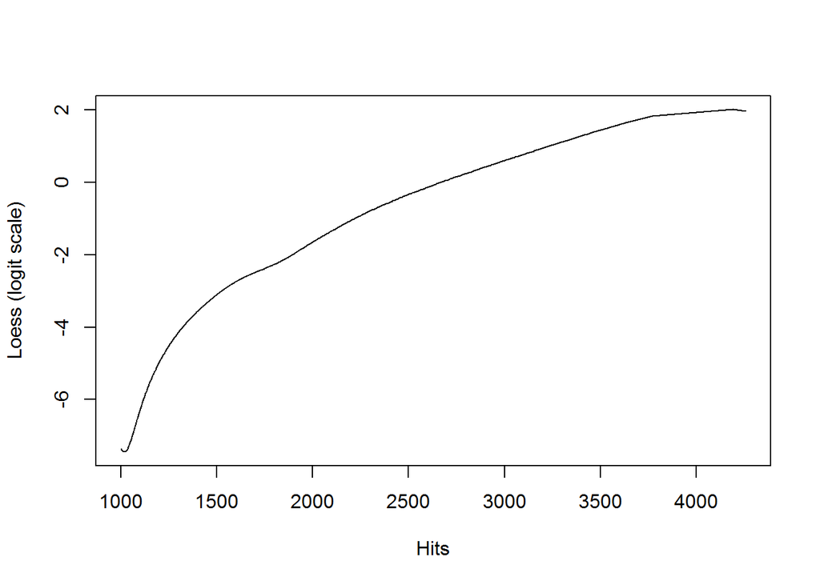

```r
lfit = loess(HOF ~ H, data = fulldata)
logitlfit = log(predict(lfit)/(1-predict(lfit)))
logitplot = data.frame(cbind(hits=fulldata$H, logitlfit))
logitplot = logitplot[order(logitplot$hits),] #these commands put the data is ascending order, which is necessary to get a smooth curve
plot(logitplot$hits, logitplot$logitlfit, type="l", xlab = "Hits", ylab = "Loess (logit scale)")
```

Does the linearity in the logit assumption appear valid in this data? If not, can you propose a fix?

# Further Reading

## Interpretation of logistic regression parameters

The *odds* and *odds ratio* are common measures when dealing with binary events. The *odds* for a binary event is the ratio of the probability that the event occurs to the probability that it does not occur; $\displaystyle \frac{p}{1-p}$, where $p$ is the probability that the event occurs. Logistic regression has the convenient property that it’s parameters can be interpreted in terms of odds.

## The logit link

We have previously seen the logistic regression model expressed in terms of estimated probability; $E(Y | X) = \pi(X) =\displaystyle \frac{e^{\beta_0+\beta_1 X}} {1+e^{\beta_0+ \beta_1 X}}$. Sometimes, writing the model in terms of a linear function is helpful for interpreting the model parameters. The inverse of the logistic function is the *logit function*, *logit*(p) $= ln( \displaystyle \frac{p}{1-p})$. An equivalent way to write the logistic regression model is therefore $ln( \displaystyle \frac{\pi(x)}{1-\pi(x)}) = \beta_0 + \beta_1x$. In this form, perhaps it is more clear why this model is a generalized *linear* model.

### The log-odds

Note that logit($\pi(x)$) is the natural logarithm of the odds or the *log-odds*. The estimated log-odds are then $\hat{g}(x) =ln( \displaystyle \frac{\hat{\pi}(x)}{1-\hat{\pi}(x)} ) = b_0 + b_1x$. Although the log-odds do not have a natural interpretation, exponentiating both sides give us the estimated odds, $\hat{O}(x) = \displaystyle \frac{\hat{\pi}(x)}{1-\hat{\pi}(x)} = e^{b_0 + b_1x}$.

## The odds ratio and interpreting the slope parameter

The odds ratio is … wait for it … the ratio of the odds. Specifically, it describes the odds of an event given a particular ‘exposure’, compared to the odds of the event in the absence of that ‘exposure’. The slope parameter, $\beta_1$ of the logistic regression model is the log odds ratio of the outcome for a one unit change in $x$. [Math here] Recall the logistic regression model we fit for Field Goals on Distance and Fourth Quarter.

```r
FG.mod2 = glm(FG.dat$Outcome~FG.dat$Distance+FG.dat$fourth, family = binomial)
summary(FG.mod2)
```

```
##
## Call:
## glm(formula = FG.dat$Outcome ~ FG.dat$Distance + FG.dat$fourth,
##     family = binomial)
##
## Deviance Residuals:
##     Min       1Q   Median       3Q      Max
## -2.6577   0.2082   0.3575   0.6071   1.2610
##
## Coefficients:
##                 Estimate Std. Error z value            Pr(>|z|)
## (Intercept)      6.30245    0.60738  10.377 <0.0000000000000002 ***
## FG.dat$Distance -0.11201    0.01333  -8.406 <0.0000000000000002 ***
## FG.dat$fourth    0.38118    0.26349   1.447               0.148
## ---
## Signif. codes:  0 '***' 0.001 '**' 0.01 '*' 0.05 '.' 0.1 ' ' 1
##
## (Dispersion parameter for binomial family taken to be 1)
##
##     Null deviance: 650.53  on 773  degrees of freedom
## Residual deviance: 548.63  on 771  degrees of freedom
## AIC: 554.63
##
## Number of Fisher Scoring iterations: 5
```

- What is the estimated log odds ratio for a one yard increase in Distance?
  - -0.11201
- What is the estimated odds ratio for a one yard increase in Distance?

  ```r
  exp(FG.mod2$coef[2])
  ```

  ```
  ## FG.dat$Distance
  ##       0.8940315
  ```

  0.894.
- Does this estimated odds ratio indicate that the odds of a successful field goal are more or less at a longer distance than at a shorter distance? Why?
  - This indicates that the odds of a successful field goal attempt are less at a longer distance than at a shorter distance. The estimated OR is less than one meaning that the numerator (odds of a successful attempt at Distance = d+1) is less than the denominator (odds of a successful attempt at Distance = d).
- Interpret the estimated odds ratio above.
  - The estimated odds of a field goal attempt being successful are 0.894 times as great for each additional yard away, controlling for whether or not the field goal was in the fourth quarter.
- What are the estimated odds of a successful field goal attempt at 50 yards?
  - That depends - is it the fourth quarter?
- Yes

  ```r
  exp(FG.mod2$coefficients%*%c(1,50,1))
  ```

  ```
  ##          [,1]
  ## [1,] 2.953271
  ```

- Interpret these estimated odds.
  - The estimated odds of a 50 yard field attempt being successful in the fourth quarter are 2.95. This means that the probability of making the field goal is 2.95 times the probability of not making the field goal.
- What is the estimated probability of making the field goal in the above example?

  ```r
  exp(FG.mod2$coefficients%*%c(1,50,1))/(1+ exp(FG.mod2$coefficients%*%c(1,50,1)))
  ```

  ```
  ##           [,1]
  ## [1,] 0.7470449
  ```

- What is the estimated odds ratio for a successful field goal attempt for a 10-yard increase in Distance?

  - ```r
        exp(FG.mod2$coef[2]*10)
    ```

    ```
    ## FG.dat$Distance
    ##       0.3262332
    ```

## Categorical Predictors

Categorical predictor variables, e.g. race or gender, are typically included in regression models using indicator (often (0,1)) variables. The number of indicator variables required is one fewer than the number of categories. For example, suppose a Race variable has three categories: Black, White and Other. We would create two indicator variables, $Z_1$, which is 1 for Whites and 0 otherwise and $Z_2$, which is 1 for Other and 0 otherwise. Here, Black is 0 for both variables and is referred to as the reference group. Coefficients for categorical variables have particularly nice interpretations. Assume a model with a single categorical predictor variable, e.g. $\hat{g}(sex) =ln( \displaystyle \frac{\hat{\pi}(sex)}{1-\hat{\pi}(sex)} ) = b_0 + b_1sex$.

- $e^{\beta_0}$ represents the odds of the outcome for the reference group, when all indicators are 0.
- $e^{\beta_j}$ represents the estimated odds ratio comparing the $j^{th}$ group to the reference group; a 1 unit “increase” in X

Typically, all indicator variables for a categorical predictor or either left in the model or left out. Otherwise, you have (perhaps inadvertently) recoded the variable.

What do we do if we have one level of a categorical variable that is ‘significant’ (i.e. the Wald test indicates a coefficient significantly different than 0) and another that is not? (see the GLOW model below.)

- The Likelihood ratio test is often used to compare the model with the predictor (i.e. all associated indicator variables) in the model to the one without.

```r
glow = read.csv("glow500.csv")
glow.prelim.mod = glm(FRACTURE~ AGE+ HEIGHT+ PRIORFRAC+ MOMFRAC+ ARMASSIST+ as.factor(RATERISK), data = glow, family = binomial)
summary(glow.prelim.mod)
```

```
##
## Call:
## glm(formula = FRACTURE ~ AGE + HEIGHT + PRIORFRAC + MOMFRAC +
##     ARMASSIST + as.factor(RATERISK), family = binomial, data = glow)
##
## Deviance Residuals:
##      Min        1Q    Median        3Q       Max
## -1.66692  -0.72502  -0.56338  -0.03841   2.22148
##
## Coefficients:
##                      Estimate Std. Error z value Pr(>|z|)
## (Intercept)           2.70935    3.22992   0.839  0.40157
## AGE                   0.03434    0.01305   2.632  0.00848 **
## HEIGHT               -0.04383    0.01827  -2.400  0.01640 *
## PRIORFRAC             0.64526    0.24606   2.622  0.00873 **
## MOMFRAC               0.62122    0.30698   2.024  0.04300 *
## ARMASSIST             0.44579    0.23281   1.915  0.05551 .
## as.factor(RATERISK)2  0.42202    0.27925   1.511  0.13071
## as.factor(RATERISK)3  0.70692    0.29342   2.409  0.01599 *
## ---
## Signif. codes:  0 '***' 0.001 '**' 0.01 '*' 0.05 '.' 0.1 ' ' 1
##
## (Dispersion parameter for binomial family taken to be 1)
##
##     Null deviance: 562.34  on 499  degrees of freedom
## Residual deviance: 507.50  on 492  degrees of freedom
## AIC: 523.5
##
## Number of Fisher Scoring iterations: 4
```

```r
glow.mod.minusrr = glm(FRACTURE~ AGE+ HEIGHT+ PRIORFRAC+ MOMFRAC+ ARMASSIST, data = glow, family = binomial)
summary(glow.mod.minusrr)
```

```
##
## Call:
## glm(formula = FRACTURE ~ AGE + HEIGHT + PRIORFRAC + MOMFRAC +
##     ARMASSIST, family = binomial, data = glow)
##
## Deviance Residuals:
##      Min        1Q    Median        3Q       Max
## -1.65744  -0.72598  -0.57243   0.00966   2.17091
##
## Coefficients:
##             Estimate Std. Error z value Pr(>|z|)
## (Intercept)  3.74081    3.17824   1.177  0.23919
## AGE          0.02975    0.01275   2.333  0.01964 *
## HEIGHT      -0.04635    0.01816  -2.552  0.01070 *
## PRIORFRAC    0.75259    0.23959   3.141  0.00168 **
## MOMFRAC      0.72263    0.30235   2.390  0.01684 *
## ARMASSIST    0.52372    0.22829   2.294  0.02179 *
## ---
## Signif. codes:  0 '***' 0.001 '**' 0.01 '*' 0.05 '.' 0.1 ' ' 1
##
## (Dispersion parameter for binomial family taken to be 1)
##
##     Null deviance: 562.34  on 499  degrees of freedom
## Residual deviance: 513.46  on 494  degrees of freedom
## AIC: 525.46
##
## Number of Fisher Scoring iterations: 4
```

```r
anova(glow.mod.minusrr, glow.prelim.mod, test = "Chisq")
```

```
## Analysis of Deviance Table
##
## Model 1: FRACTURE ~ AGE + HEIGHT + PRIORFRAC + MOMFRAC + ARMASSIST
## Model 2: FRACTURE ~ AGE + HEIGHT + PRIORFRAC + MOMFRAC + ARMASSIST + as.factor(RATERISK)
##   Resid. Df Resid. Dev Df Deviance Pr(>Chi)
## 1       494     513.46
## 2       492     507.50  2   5.9587  0.05083 .
## ---
## Signif. codes:  0 '***' 0.001 '**' 0.01 '*' 0.05 '.' 0.1 ' ' 1
```

The p-value is marginally significant. If there is a clinical reason to leave RATERISK in the model, it is probably best to leave it (both indicators) in the model (this may also be true even with a very large p-value).

Another alternative - consider ‘collapsing’ or combining categories of the categorical variable. This should **only** be done if the new categories make sense.

For example, in the glow data, the Wald test tells us that there is not a significant difference (when predicting FRACTURE) in RATERISK1 (self-reported risk of fracture = less than others of the same age) and RATERISK2 (self-reported risk of fracture = same as others of the same age). Perhaps it makes sense to combine these two levels, resulting in a dichotomous variable with levels ‘the same as or less than others’ and ‘greater than others’. On the other hand, even if no difference was detected, it probably would not make sense to combine self-reported risk ‘less than others’ with ‘greater than others’.

Note that combining levels of categorical variables makes it impossible to estimate the log-odds of the original categories. When possible, subject matter experts should be consulted prior to collapsing levels of categorical variables. The R code and output below combines levels 1 and 2 of RATERISK.

```r
glow$RATERISK2 = glow$RATERISK==3
glow.mod.rrcomb = glm(FRACTURE~ AGE+ HEIGHT+ PRIORFRAC+ MOMFRAC+ ARMASSIST+RATERISK2, data = glow, family = binomial)
summary(glow.mod.rrcomb)
```

```
##
## Call:
## glm(formula = FRACTURE ~ AGE + HEIGHT + PRIORFRAC + MOMFRAC +
##     ARMASSIST + RATERISK2, family = binomial, data = glow)
##
## Deviance Residuals:
##      Min        1Q    Median        3Q       Max
## -1.68467  -0.73084  -0.56923  -0.03344   2.22601
##
## Coefficients:
##               Estimate Std. Error z value Pr(>|z|)
## (Intercept)    3.40658    3.17704   1.072  0.28361
## AGE            0.03318    0.01295   2.563  0.01039 *
## HEIGHT        -0.04631    0.01813  -2.555  0.01063 *
## PRIORFRAC      0.66416    0.24521   2.709  0.00676 **
## MOMFRAC        0.66402    0.30558   2.173  0.02978 *
## ARMASSIST      0.47272    0.23133   2.044  0.04100 *
## RATERISK2TRUE  0.45792    0.23806   1.924  0.05441 .
## ---
## Signif. codes:  0 '***' 0.001 '**' 0.01 '*' 0.05 '.' 0.1 ' ' 1
##
## (Dispersion parameter for binomial family taken to be 1)
##
##     Null deviance: 562.34  on 499  degrees of freedom
## Residual deviance: 509.82  on 493  degrees of freedom
## AIC: 523.82
##
## Number of Fisher Scoring iterations: 4
```

```r
anova(glow.mod.minusrr, glow.prelim.mod, test = "Chisq")
```

```
## Analysis of Deviance Table
##
## Model 1: FRACTURE ~ AGE + HEIGHT + PRIORFRAC + MOMFRAC + ARMASSIST
## Model 2: FRACTURE ~ AGE + HEIGHT + PRIORFRAC + MOMFRAC + ARMASSIST + as.factor(RATERISK)
##   Resid. Df Resid. Dev Df Deviance Pr(>Chi)
## 1       494     513.46
## 2       492     507.50  2   5.9587  0.05083 .
## ---
## Signif. codes:  0 '***' 0.001 '**' 0.01 '*' 0.05 '.' 0.1 ' ' 1
```

## Interactions

One important aspect of multivariable logistic regression modeling is to assess to what extent, if any, the log-odds of one predictor variable changes depending on the value of another predictor variable When the odds ratio of one variable is not constant over values of another variable, the two variables have a statistical interaction (also referred to as effect modification). Statistical interactions are included in logistic regression models (and other forms of regression models) by including a product term. The most simple version of an interaction would simply be $X_j*X_k$, however, interactions need not be linear modifications.

When an interaction term is included in a model, it is accepted practice to also include all of the main effects terms (i.e. in the previous example, if an $X_j*X_k$ interaction term is in the model then $X_j$ and $X_k$ should also be in the model as main effects terms). This ensures that the model is *hierarchically well defined*.

Note that interactions between categorical predictors with $> 2$ levels will add multiple additional terms to the model.

Interaction terms may include three or more variables but it is not common to include higher than two-way interactions unless there is a scientific reason to do so.

## Practical Example

The GLOW data set contains information on 500 women over age 55 enrolled in the Global Longitudinal Study of of Osteoporosis in Women. The goal is to identify risk factors for fracture (FRACTURE). Assume that the preliminary main effects model previously found was
$$g(Y) = b_0 + b_1 AGE + b_2 HEIGHT + b_3 PRIORFRAC + b_4 MOMFRAC$$
$$+ b_5 ARMASSIST + b_6 RATERISK2 + b_7 RATERISK3$$
. Propose a final model using 5 - 7 of the purposeful selection algorithm previously described to included deciding appropriate levels for RATERISK.